# Отчёт по лабораторной работе №2

Шайхльбарин Денис

2024-04-08

## 1. Точечные оценки параметров методом моментов

Создаем выборки

```r
# Генерируем выборки
set.seed(0)
x1 = rnorm(800, 65, 78) # Нормальный закон распределения
x2 = rexp(700, 30) # Показательный ЗР
x3 = rbinom(700, 45, 0.8) # Биномиальный ЗР
```

Исходные данные:

```r
str(x1)
```

```
##  num [1:800] 163.5 39.6 168.7 164.2 97.3 ...
```

```r
str(x2)
```

```
##  num [1:700] 0.07716 0.04982 0.10978 0.09527 0.00413 ...
```

```r
str(x3)
```

```
##  int [1:700] 38 39 37 34 39 37 37 34 36 34 ...
```

Для нормального закона:

```r
a = mean(x1); a
```

```
## [1] 64.53058
```

```r
si = sd(x1); si
```

```
## [1] 76.21217
```

Для показательного закона:

```r
lam = 1 / mean(x2); lam
```

```
## [1] 29.63138
```

Для биномиального закона:

```r
p = mean(x3) / 45; p
```

```
## [1] 0.7994603
```

```r
n = mean(x3) / 0.8; n
```

```
## [1] 44.96964
```

## 2.1. Сравнение способов оценивания (НЗР)

Нормальный закон распределения, 10 величин

```r
n <- 10 # 10 величин
varCount <- 20 # 20 выборок
foo = rnorm # НЗР
xs <- foo(n * varCount, 65, 78) # count, m, sigma
M <- matrix(xs, varCount, n)
```

Метод моментов

```r
result111 <- apply(M, 1, function(x)(2 / n)*sum(x))
str(result111)
```

```
##  num [1:20] 28.5 171.2 163.8 131.5 198.4 ...
```

Метод наибольшего правдоподобия

```r
result112 <- apply(M, 1, function(x)((n+1) / n)*max(x))
str(result112)
```

```
##  num [1:20] 164 219 322 157 310 ...
```

Метод порядковых статистик

```r
result113 <- apply(M, 1, function(x)(2*quantile(x, c(0.5))))
str(result113)
```

```
##  num [1:20] 55.4 167.5 146.6 153.8 152.3 ...
```

График

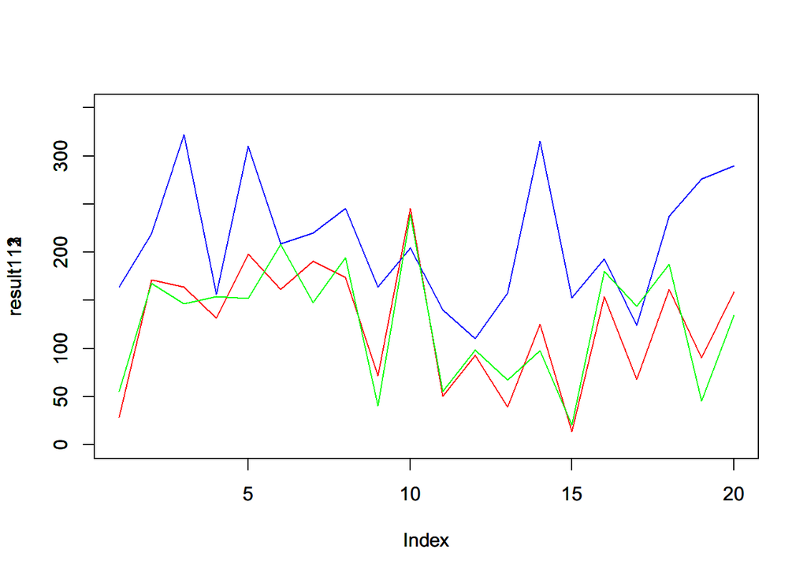

```r
plot(result111, type = "l", ylim = c(0, 350))
lines(result111, col = "red")
par(new = T)
plot(result112, type = "l", ylim = c(0, 350))
lines(result112, col = "blue")
par(new = T)
plot(result113, type = "l", ylim = c(0, 350))
lines(result113, col = "green")
```

Среднеквадратичное отклонение:

```r
p111 <- sd(result111)
p112 <- sd(result112)
p113 <- sd(result113)
```

Наибольшее:

```r
max111 <- max(result111)
max112 <- max(result112)
max113 <- max(result113)
```

Наименьшее:

```r
min111 <- min(result111)
min112 <- min(result112)
min113 <- min(result113)
```

Размах:

```r
R111 <- max111-min111
R112 <- max112-min112
R113 <- max113-min113
```

.

-={X}=-={X}=-={X}=-={X}=-={X}=-={X}=-={X}=-={X}=-

.

Нормальный закон распределения, 40 величин

```r
n <- 40 # 40 величин
varCount <- 20 # 20 выборок
foo = rnorm # НЗР
xs <- foo(n * varCount, 65, 78) # count, m, sigma
M <- matrix(xs, varCount, n)
```

Метод моментов

```r
result121 <- apply(M, 1, function(x)(2 / n)*sum(x))
str(result121)
```

```
##  num [1:20] 132 134 114 135 160 ...
```

Метод наибольшего правдоподобия

```r
result122 <- apply(M, 1, function(x)((n+1) / n)*max(x))
str(result122)
```

```
##  num [1:20] 204 240 184 222 281 ...
```

Метод порядковых статистик

```r
result123 <- apply(M, 1, function(x)(2*quantile(x, c(0.5))))
str(result123)
```

```
##  num [1:20] 142 133 90 177 121 ...
```

График

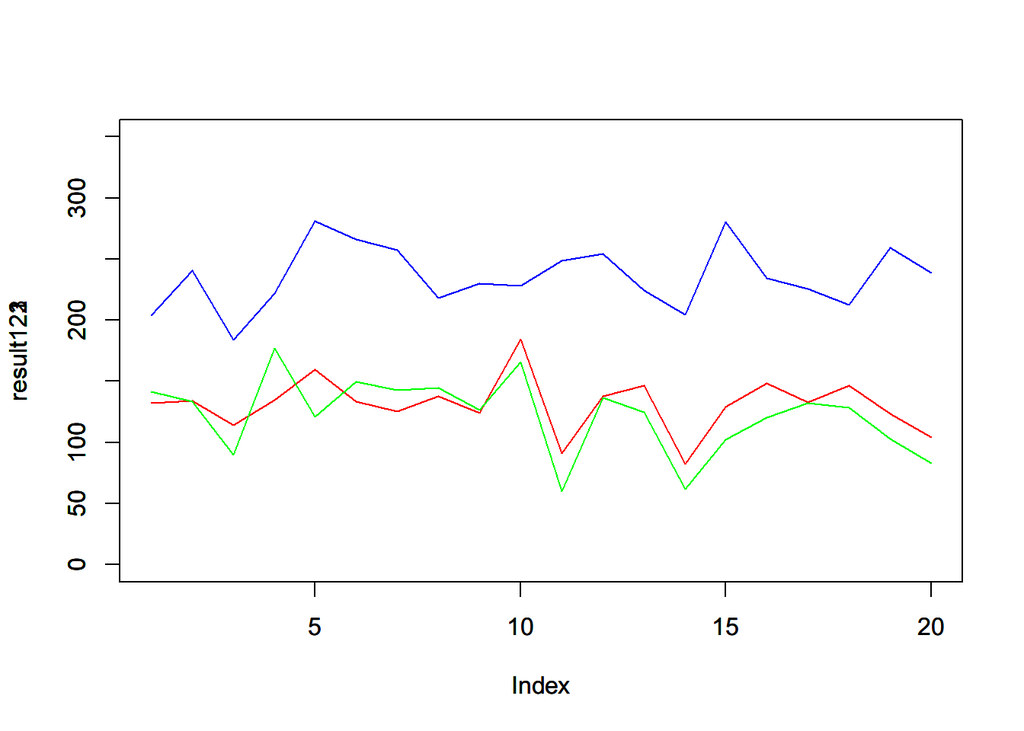

```r
plot(result121, type = "l", ylim = c(0, 350))
lines(result121, col = "red")
par(new = T)
plot(result122, type = "l", ylim = c(0, 350))
lines(result122, col = "blue")
par(new = T)
plot(result123, type = "l", ylim = c(0, 350))
lines(result123, col = "green")
```

Среднеквадратичное отклонение:

```r
p121 <- sd(result121)
p122 <- sd(result122)
p123 <- sd(result123)
```

Наибольшее:

```r
max121 <- max(result121)
max122 <- max(result122)
max123 <- max(result123)
```

Наименьшее:

```r
min121 <- min(result121)
min122 <- min(result122)
min123 <- min(result123)
```

Размах:

```r
R121 <- max121-min121
R122 <- max122-min122
R123 <- max123-min123
```

.

-={X}=-={X}=-={X}=-={X}=-={X}=-={X}=-={X}=-={X}=-

.

Нормальный закон распределения, 160 величин

```r
n <- 160 # 160 величин
varCount <- 20 # 20 выборок
foo = rnorm # НЗР
xs <- foo(n * varCount, 65, 78) # count, m, sigma
M <- matrix(xs, varCount, n)
```

Метод моментов

```r
result131 <- apply(M, 1, function(x)(2 / n)*sum(x))
str(result131)
```

```
##  num [1:20] 121 139 120 141 123 ...
```

Метод наибольшего правдоподобия

```r
result132 <- apply(M, 1, function(x)((n+1) / n)*max(x))
str(result132)
```

```
##  num [1:20] 315 290 236 233 222 ...
```

Метод порядковых статистик

```r
result133 <- apply(M, 1, function(x)(2*quantile(x, c(0.5))))
str(result133)
```

```
##  num [1:20] 116 139 126 173 135 ...
```

График

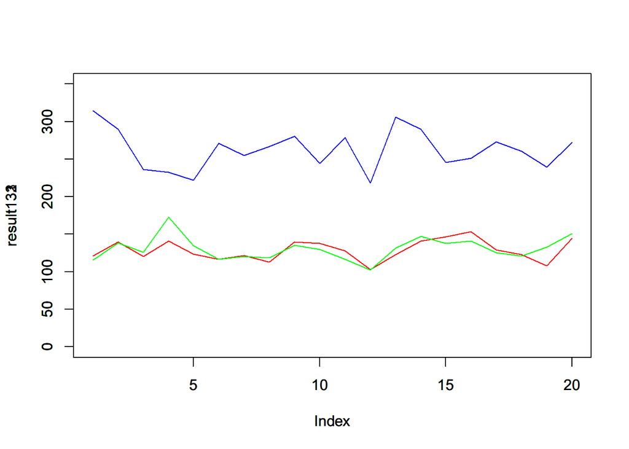

```r
plot(result131, type = "l", ylim = c(0, 350))
lines(result131, col = "red")
par(new = T)
plot(result132, type = "l", ylim = c(0, 350))
lines(result132, col = "blue")
par(new = T)
plot(result133, type = "l", ylim = c(0, 350))
lines(result133, col = "green")
```

Среднеквадратичное отклонение:

```r
p131 <- sd(result131)
p132 <- sd(result132)
p133 <- sd(result133)
```

Наибольшее:

```r
max131 <- max(result131)
max132 <- max(result132)
max133 <- max(result133)
```

Наименьшее:

```r
min131 <- min(result131)
min132 <- min(result132)
min133 <- min(result133)
```

Размах:

```r
R131 <- max131-min131
R132 <- max132-min132
R133 <- max133-min133
```

Сравнение отклонений, наибольших, наименьших и размахов:

```r
n1_1 <- c(p111, p112, p113, max111, max112, max113, min111, min112, min113, R111, R112, R113)
n1_2 <- c(p121, p122, p123, max121, max122, max123, min121, min122, min123, R121, R122, R123)
n1_3 <- c(p131, p132, p133, max131, max132, max133, min131, min132, min133, R131, R132, R133)

result_norm <- cbind(n1_1, n1_2, n1_3)
rownames(result_norm) <- c('p1', 'p2', 'p3', 'max1', 'max2', 'max3', 'min1', 'min2', 'min3', 'R1', 'R2', 'R3')
result_norm
```

```
##           n1_1      n1_2      n1_3
## p1    63.99312  22.60544  13.79847
## p2    65.77418  25.72229  26.68610
## p3    63.01754  31.04548  15.43493
## max1 245.63224 184.62381 153.64579
## max2 321.96983 281.20464 314.83336
## max3 239.44363 176.93750 172.61606
## min1  13.95369  82.11634 102.92269
## min2 110.28466 184.16280 218.45864
## min3  20.51325  59.92081 102.46662
## R1   231.67855 102.50748  50.72311
## R2   211.68518  97.04184  96.37472
## R3   218.93038 117.01670  70.14945
```

Сравнение среднеквадратических отклонений:

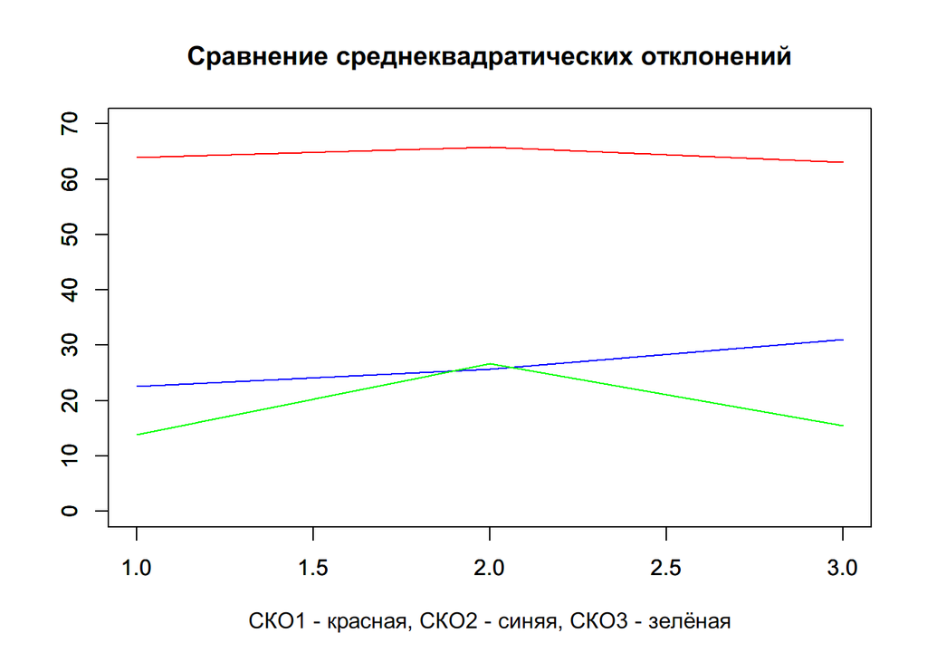

```r
v1_1 <- c(p111, p112, p113)
v1_2 <- c(p121, p122, p123)
v1_3 <- c(p131, p132, p133)

plot(v1_1, col = "red", main = "Cравнение среднеквадратических отклонений", ylab = "", xlab = "СКО1 - красная, СКО2 - синяя, СКО3 - зелёная", type = "l", ylim = c(0, 70))
par(new = T)
plot(v1_2, col = "blue", ylab = "", xlab = "", type = "l", ylim = c(0, 70))
par(new = T)
plot(v1_3, col = "green", ylab = "", xlab = "", type = "l", ylim = c(0, 70))
```

## 2.2. Сравнение способов оценивания (ПЗР)

Показательный (экспоненциальный) закон распределения, 10 величин

```r
n <- 10 # 10 величин
varCount <- 20 # 20 выборок
foo = rexp # ПЗР
xs <- foo(n * varCount, 30) # count, lamda
M <- matrix(xs, varCount, n)
```

Метод моментов

```r
result211 <- apply(M, 1, function(x)(2 / n)*sum(x))
str(result211)
```

```
##  num [1:20] 0.0554 0.0719 0.0505 0.0634 0.0536 ...
```

Метод наибольшего правдоподобия

```r
result212 <- apply(M, 1, function(x)((n+1) / n)*max(x))
str(result212)
```

```
##  num [1:20] 0.0554 0.1503 0.0944 0.0809 0.0714 ...
```

Метод порядковых статистик

```r
result213 <- apply(M, 1, function(x)(2*quantile(x, c(0.5))))
str(result213)
```

```
##  num [1:20] 0.0516 0.0459 0.0304 0.0484 0.0433 ...
```

График

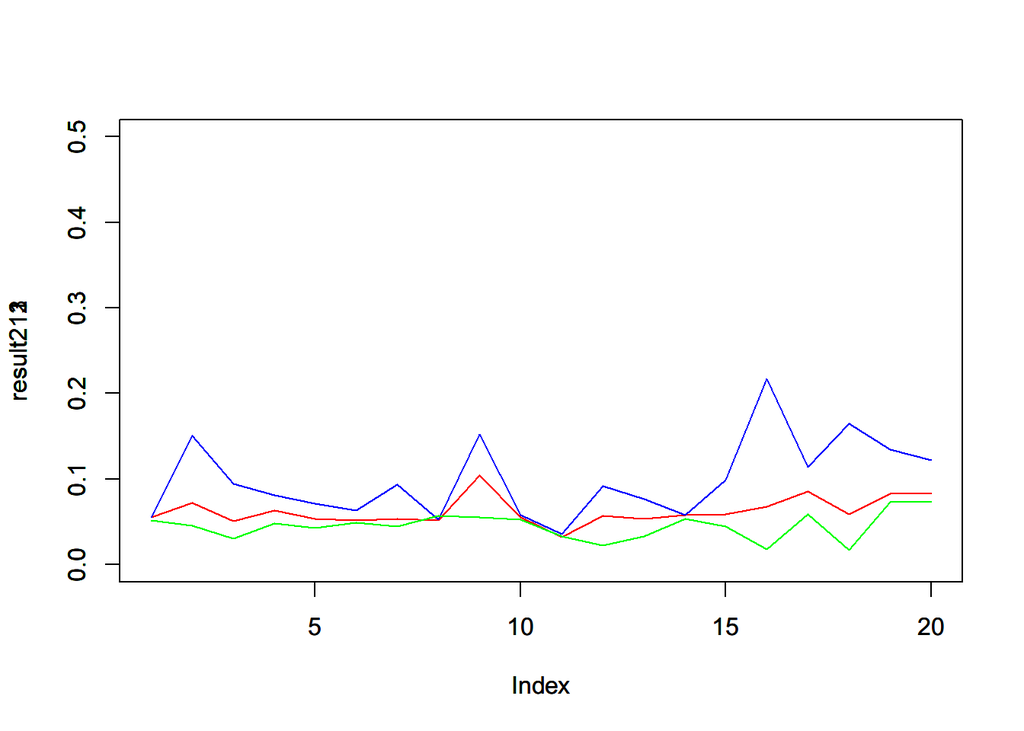

```r
plot(result211, type = "l", ylim = c(0, 0.5))
lines(result211, col = "red")
par(new = T)
plot(result212, type = "l", ylim = c(0, 0.5))
lines(result212, col = "blue")
par(new = T)
plot(result213, type = "l", ylim = c(0, 0.5))
lines(result213, col = "green")
```

Среднеквадратичное отклонение:

```r
p211 <- sd(result211)
p212 <- sd(result212)
p213 <- sd(result213)
```

Наибольшее:

```r
max211 <- max(result211)
max212 <- max(result212)
max213 <- max(result213)
```

Наименьшее:

```r
min211 <- min(result211)
min212 <- min(result212)
min213 <- min(result213)
```

Размах:

```r
R211 <- max211-min211
R212 <- max212-min212
R213 <- max213-min213
```

.

-={X}=-={X}=-={X}=-={X}=-={X}=-={X}=-={X}=-={X}=-

.

Показательный (экспоненциальный) закон распределения, 40 величин

```r
n <- 40 # 40 величин
varCount <- 20 # 20 выборок
foo = rexp # ПЗР
xs <- foo(n * varCount, 30) # count, lamda
M <- matrix(xs, varCount, n)
```

Метод моментов

```r
result221 <- apply(M, 1, function(x)(2 / n)*sum(x))
str(result221)
```

```
##  num [1:20] 0.0441 0.0813 0.0638 0.0699 0.055 ...
```

Метод наибольшего правдоподобия

```r
result222 <- apply(M, 1, function(x)((n+1) / n)*max(x))
str(result222)
```

```
##  num [1:20] 0.119 0.146 0.158 0.132 0.138 ...
```

Метод порядковых статистик

```r
result223 <- apply(M, 1, function(x)(2*quantile(x, c(0.5))))
str(result223)
```

```
##  num [1:20] 0.0328 0.0643 0.0423 0.0563 0.0321 ...
```

График

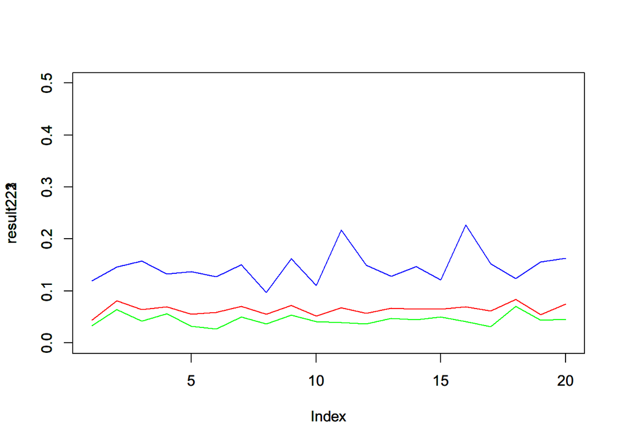

```r
plot(result221, type = "l", ylim = c(0, 0.5))
lines(result221, col = "red")
par(new = T)
plot(result222, type = "l", ylim = c(0, 0.5))
lines(result222, col = "blue")
par(new = T)
plot(result223, type = "l", ylim = c(0, 0.5))
lines(result223, col = "green")
```

Среднеквадратичное отклонение:

```r
p221 <- sd(result221)
p222 <- sd(result222)
p223 <- sd(result223)
```

Наибольшее:

```r
max221 <- max(result221)
max222 <- max(result222)
max223 <- max(result223)
```

Наименьшее:

```r
min221 <- min(result221)
min222 <- min(result222)
min223 <- min(result223)
```

Размах:

```r
R221 <- max221-min221
R222 <- max222-min222
R223 <- max223-min223
```

.

-={X}=-={X}=-={X}=-={X}=-={X}=-={X}=-={X}=-={X}=-

.

Показательный (экспоненциальный) закон распределения, 160 величин

```r
n <- 160 # 160 величин
varCount <- 20 # 20 выборок
foo = rexp # ПЗР
xs <- foo(n * varCount, 30) # count, lamda
M <- matrix(xs, varCount, n)
```

Метод моментов

```r
result231 <- apply(M, 1, function(x)(2 / n)*sum(x))
str(result231)
```

```
##  num [1:20] 0.0692 0.0607 0.0669 0.0699 0.0662 ...
```

Метод наибольшего правдоподобия

```r
result232 <- apply(M, 1, function(x)((n+1) / n)*max(x))
str(result232)
```

```
##  num [1:20] 0.205 0.122 0.184 0.256 0.261 ...
```

Метод порядковых статистик

```r
result233 <- apply(M, 1, function(x)(2*quantile(x, c(0.5))))
str(result233)
```

```
##  num [1:20] 0.046 0.0421 0.0534 0.0452 0.0479 ...
```

График

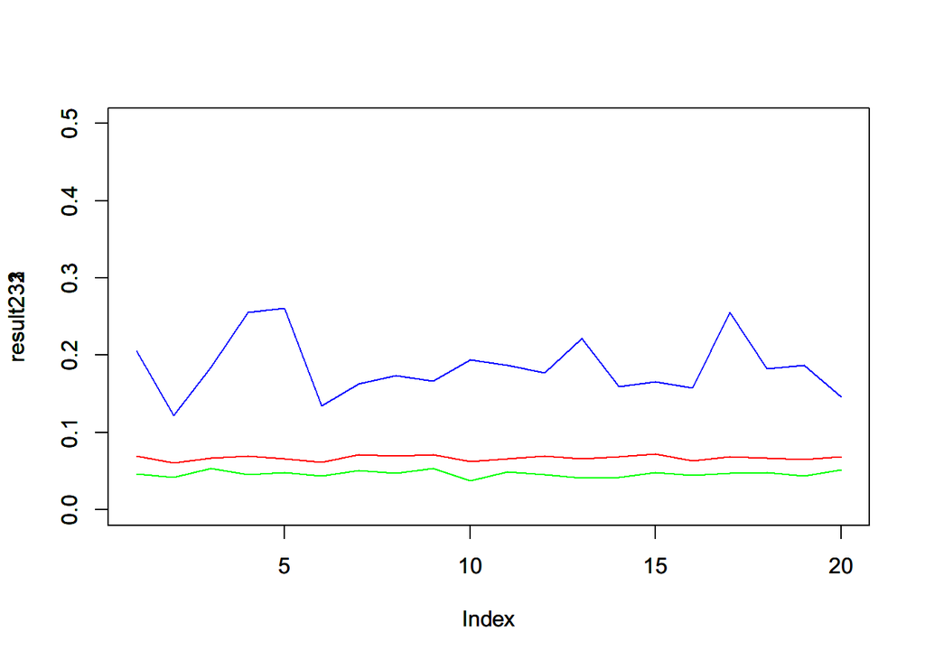

```r
plot(result231, type = "l", ylim = c(0, 0.5))
lines(result231, col = "red")
par(new = T)
plot(result232, type = "l", ylim = c(0, 0.5))
lines(result232, col = "blue")
par(new = T)
plot(result233, type = "l", ylim = c(0, 0.5))
lines(result233, col = "green")
```

Среднеквадратичное отклонение:

```r
p231 <- sd(result231)
p232 <- sd(result232)
p233 <- sd(result233)
```

Наибольшее:

```r
max231 <- max(result231)
max232 <- max(result232)
max233 <- max(result233)
```

Наименьшее:

```r
min231 <- min(result231)
min232 <- min(result232)
min233 <- min(result233)
```

Размах:

```r
R231 <- max231-min231
R232 <- max232-min232
R233 <- max233-min233
```

Сравнение отклонений, наибольших, наименьших и размахов:

```r
n2_1 <- c(p211, p212, p213, max211, max212, max213, min211, min212, min213, R211, R212, R213)
n2_2 <- c(p221, p222, p223, max221, max222, max223, min221, min222, min223, R221, R222, R223)
n2_3 <- c(p231, p232, p233, max231, max232, max233, min231, min232, min233, R231, R232, R233)

result_norm <- cbind(n2_1, n2_2, n2_3)
rownames(result_norm) <- c('p1', 'p2', 'p3', 'max1', 'max2', 'max3', 'min1', 'min2', 'min3', 'R1', 'R2', 'R3')
result_norm
```

```
##            n2_1        n2_2        n2_3
## p1   0.01620223 0.009934261 0.003255323
## p2   0.04602637 0.031553239 0.038666660
## p3   0.01591063 0.011031203 0.004120987
## max1 0.10446371 0.083623785 0.072170818
## max2 0.21754218 0.226960642 0.260638101
## max3 0.07363420 0.070387421 0.053388379
## min1 0.03235527 0.044064804 0.060669746
## min2 0.03557832 0.097488738 0.122065983
## min3 0.01737061 0.026848559 0.037404793
## R1   0.07210844 0.039558981 0.011501073
## R2   0.18196385 0.129471904 0.138572118
## R3   0.05626359 0.043538862 0.015983586
```

Сравнение среднеквадратических отклонений:

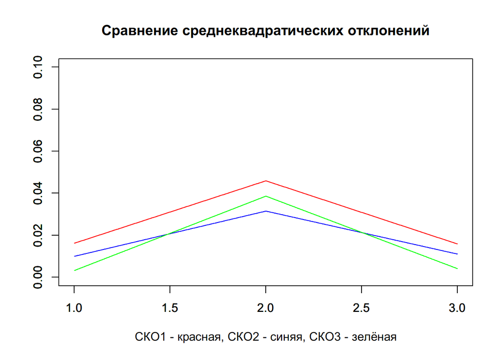

```r
v2_1 <- c(p211, p212, p213)
v2_2 <- c(p221, p222, p223)
v2_3 <- c(p231, p232, p233)

plot(v2_1, col = "red", main = "Cравнение среднеквадратических отклонений", ylab = "", xlab = "СКО1 - красная, СКО2 - синяя, СКО3 - зелёная", type = "l", ylim = c(0, 0.1))
par(new = T)
plot(v2_2, col = "blue", ylab = "", xlab = "", type = "l", ylim = c(0, 0.1))
par(new = T)
plot(v2_3, col = "green", ylab = "", xlab = "", type = "l", ylim = c(0, 0.1))
```

## 3. Проверка на нормальность распределения

ВВП Индии в млрд. $ за 1960-2022 гг. https://www.kaggle.com/datasets/dheerajmukati/india-gdp-19602022

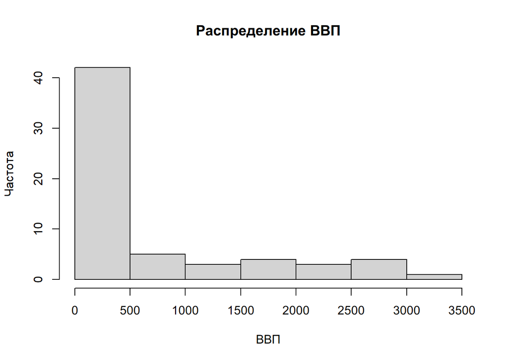

```r
z <- read.csv(file = "India_GDP_1960-2022.csv", header = TRUE);
x <- z$GDP
hist(x, main = "Распределение ВВП", xlab = "ВВП", ylab = "Частота")
```

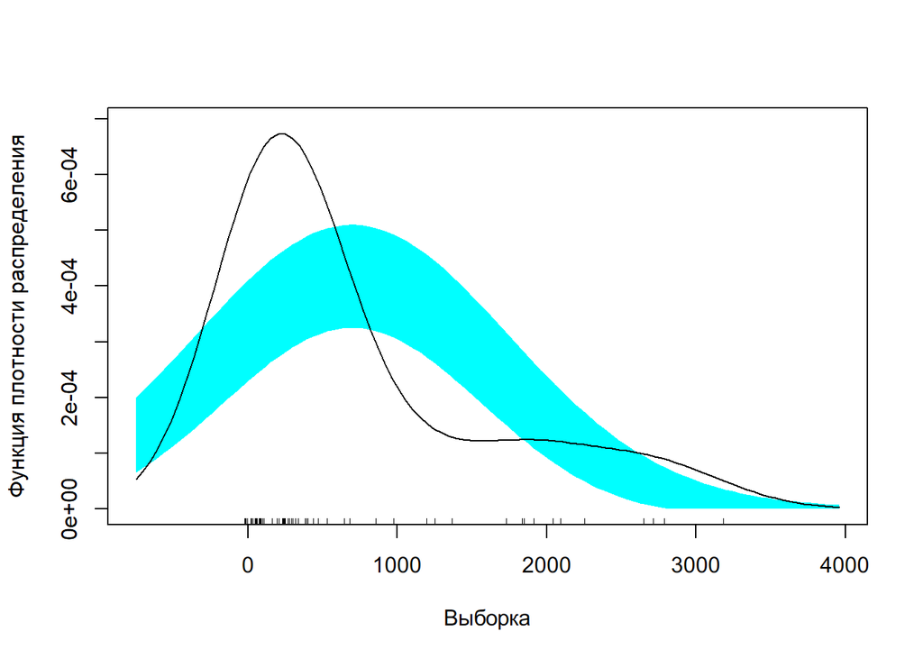

```r
library(sm)
sm.density(x, model = "Normal", xlab = "Выборка", ylab = "Функция плотности распределения")
```

```r
library(nortest)
lillie.test(x)
```

```
##
##  Lilliefors (Kolmogorov-Smirnov) normality test
##
## data:  x
## D = 0.2776, p-value = 5.195e-13
```

По результатам теста (значение p значительно меньше 0.05) можем сделать вывод, что наша нулевая гепотеза о выборке из генеральной совокупности с нормальным распределением отвергается.